# GDA Case Study 1

May Wu

2026-02-04

This case study analyzes bike usage based on data from 2019 and 2020 Q1. The data source is provided by Motivate International Inc., a well-known bike-sharing operator.

Objective: To explore how members and non-members of the bike-sharing service differ in their riding behavior.

Approach: We first import and inspect the data, then clean it, compute descriptive statistics, and create visualizations. Key findings are summarized at the end.

## 1. Data preparation

### 1.1 Import Data

```r
#load libraries
library(dplyr)
#Inspect raw data
df_2019 <- read.csv('Divvy_Trips_2019_Q1.csv')
df_2020 <- read.csv('Divvy_Trips_2020_Q1.csv')
str(df_2019)
```

```
## 'data.frame':    365069 obs. of  14 variables:
##  $ trip_id          : int  21742443 21742444 21742445 21742446 21742447 21742448 21742449 21742450 21742451 21742452 ...
##  $ start_time       : chr  "2019-01-01 0:04:37" "2019-01-01 0:08:13" "2019-01-01 0:13:23" "2019-01-01 0:13:45" ...
##  $ end_time         : chr  "2019-01-01 0:11:07" "2019-01-01 0:15:34" "2019-01-01 0:27:12" "2019-01-01 0:43:28" ...
##  $ bikeid           : int  2167 4386 1524 252 1170 2437 2708 2796 6205 3939 ...
##  $ tripduration     : int  390 441 829 1783 364 216 177 100 1727 336 ...
##  $ from_station_id  : int  199 44 15 123 173 98 98 211 150 268 ...
##  $ from_station_name: chr  "Wabash Ave & Grand Ave" "State St & Randolph St" "Racine Ave & 18th St" "California Ave & Milwaukee Ave" ...
##  $ to_station_id    : int  84 624 644 176 35 49 49 142 148 141 ...
##  $ to_station_name  : chr  "Milwaukee Ave & Grand Ave" "Dearborn St & Van Buren St (*)" "Western Ave & Fillmore St (*)" "Clark St & Elm St" ...
##  $ usertype         : chr  "Subscriber" "Subscriber" "Subscriber" "Subscriber" ...
##  $ gender           : chr  "Male" "Female" "Female" "Male" ...
##  $ birthyear        : int  1989 1990 1994 1993 1994 1983 1984 1990 1995 1996 ...
##  $ ride_length      : chr  "0:06:30" "0:07:21" "0:13:49" "0:29:43" ...
##  $ day_of_week      : int  2 2 2 2 2 2 2 2 2 2 ...
```

```r
str(df_2020)
```

```
## 'data.frame':    426887 obs. of  15 variables:
##  $ ride_id           : chr  "EACB19130B0CDA4A" "8FED874C809DC021" "789F3C21E472CA96" "C9A388DAC6ABF313" ...
##  $ rideable_type     : chr  "docked_bike" "docked_bike" "docked_bike" "docked_bike" ...
##  $ started_at        : chr  "2020-01-21 20:06:59" "2020-01-30 14:22:39" "2020-01-09 19:29:26" "2020-01-06 16:17:07" ...
##  $ ended_at          : chr  "2020-01-21 20:14:30" "2020-01-30 14:26:22" "2020-01-09 19:32:17" "2020-01-06 16:25:56" ...
##  $ start_station_name: chr  "Western Ave & Leland Ave" "Clark St & Montrose Ave" "Broadway & Belmont Ave" "Clark St & Randolph St" ...
##  $ start_station_id  : int  239 234 296 51 66 212 96 96 212 38 ...
##  $ end_station_name  : chr  "Clark St & Leland Ave" "Southport Ave & Irving Park Rd" "Wilton Ave & Belmont Ave" "Fairbanks Ct & Grand Ave" ...
##  $ end_station_id    : int  326 318 117 24 212 96 212 212 96 100 ...
##  $ start_lat         : num  42 42 41.9 41.9 41.9 ...
##  $ start_lng         : num  -87.7 -87.7 -87.6 -87.6 -87.6 ...
##  $ end_lat           : num  42 42 41.9 41.9 41.9 ...
##  $ end_lng           : num  -87.7 -87.7 -87.7 -87.6 -87.6 ...
##  $ member_casual     : chr  "member" "member" "member" "member" ...
##  $ ride_length       : chr  "0:07:31" "0:03:43" "0:02:51" "0:08:49" ...
##  $ day_of_week       : int  2 4 4 1 4 5 5 5 5 5 ...
```

```r
#Correct data type
df_2019$day_of_week <- as.character(df_2019$day_of_week)
df_2020$day_of_week <- as.character(df_2020$day_of_week)
```

df_2019: Columns K and L contain missing values; values in column E are inconsistent.

df_2020: Contains incomplete ride records;

Converting trip durations in both tables into minutes before merging the tables

### 1.2 Unify trip duration/length unit

```r
# df_2019: calculate ride_length, and compare it with column duration
df_2019$ride_length_sec <- sapply(df_2019$ride_length, function(x) {
  hms <- unlist(strsplit(x, ":"))
  as.numeric(hms[1])*3600 + as.numeric(hms[2])*60 + as.numeric(hms[3])
})
df_2019$ride_length_min <- df_2019$ride_length_sec / 60 #convert ride_length to minutes

# df_2020: calculate ride_length
df_2020$ride_length_sec <- sapply(df_2020$ride_length, function(x) {
  hms <- unlist(strsplit(x, ":"))
  as.numeric(hms[1])*3600 + as.numeric(hms[2])*60 + as.numeric(hms[3])
})
df_2020$ride_length_min <- df_2020$ride_length_sec / 60 #convert ride_length to minutes
```

### 1.3 Merge dataset

The two datasets have slightly different column names. We align 2020 column names and add missing columns to match 2019 schema, then combine the datasets into a single table.

```r
# Check column names used in both tables
colnames(df_2019)
```

```
##  [1] "trip_id"           "start_time"        "end_time"
##  [4] "bikeid"            "tripduration"      "from_station_id"
##  [7] "from_station_name" "to_station_id"     "to_station_name"
## [10] "usertype"          "gender"            "birthyear"
## [13] "ride_length"       "day_of_week"       "ride_length_sec"
## [16] "ride_length_min"
```

```r
colnames(df_2020)
```

```
##  [1] "ride_id"            "rideable_type"      "started_at"
##  [4] "ended_at"           "start_station_name" "start_station_id"
##  [7] "end_station_name"   "end_station_id"     "start_lat"
## [10] "start_lng"          "end_lat"            "end_lng"
## [13] "member_casual"      "ride_length"        "day_of_week"
## [16] "ride_length_sec"    "ride_length_min"
```

```r
# adding unique rows of df_2019 to df_2020
df_2020$bikeid <- NA
df_2020$tripduration <- NA
df_2020$gender <- NA
df_2020$birthyear <- NA

# rename df_2020 columns to match df_2019
colnames(df_2020)[colnames(df_2020) == "ride_id"] <- "trip_id"
colnames(df_2020)[colnames(df_2020) == "started_at"] <- "start_time"
colnames(df_2020)[colnames(df_2020) == "ended_at"] <- "end_time"
colnames(df_2020)[colnames(df_2020) == "start_station_id"] <- "from_station_id"
colnames(df_2020)[colnames(df_2020) == "start_station_name"] <- "from_station_name"
colnames(df_2020)[colnames(df_2020) == "end_station_id"] <- "to_station_id"
colnames(df_2020)[colnames(df_2020) == "end_station_name"] <- "to_station_name"
colnames(df_2020)[colnames(df_2020) == "member_casual"] <- "usertype"

# order columns
df_2020 <- df_2020[, colnames(df_2019)]

# combine two tables
combined_df <- rbind(df_2019, df_2020)
```

Next, we inspect the ride lengths for any unusual values.

### 1.4 Remove outliers

We inspect ride durations and identify extreme values exceeding 24 hours (1440 minutes), likely due to data recording errors. One extreme example is 10,628,400 seconds (~123 days). These outliers are removed to prevent skewing analyses of typical bike usage.

```r
# mark outliers
outliers <- (!is.na(combined_df$ride_length_min) & combined_df$ride_length_min > 1440) |
            (!is.na(combined_df$tripduration) & combined_df$tripduration > 1440*60)

sum(outliers, na.rm = TRUE)
```

```
## [1] 482
```

```r
# remove them
combined_df_clean <- combined_df[!outliers, ]

head(combined_df_clean)
```

```
##    trip_id         start_time           end_time bikeid tripduration
## 1 21742443 2019-01-01 0:04:37 2019-01-01 0:11:07   2167          390
## 2 21742444 2019-01-01 0:08:13 2019-01-01 0:15:34   4386          441
## 3 21742445 2019-01-01 0:13:23 2019-01-01 0:27:12   1524          829
## 4 21742446 2019-01-01 0:13:45 2019-01-01 0:43:28    252         1783
## 5 21742447 2019-01-01 0:14:52 2019-01-01 0:20:56   1170          364
## 6 21742448 2019-01-01 0:15:33 2019-01-01 0:19:09   2437          216
##   from_station_id                   from_station_name to_station_id
## 1             199              Wabash Ave & Grand Ave            84
## 2              44              State St & Randolph St           624
## 3              15                Racine Ave & 18th St           644
## 4             123      California Ave & Milwaukee Ave           176
## 5             173 Mies van der Rohe Way & Chicago Ave            35
## 6              98          LaSalle St & Washington St            49
##                  to_station_name   usertype gender birthyear ride_length
## 1      Milwaukee Ave & Grand Ave Subscriber   Male      1989     0:06:30
## 2 Dearborn St & Van Buren St (*) Subscriber Female      1990     0:07:21
## 3  Western Ave & Fillmore St (*) Subscriber Female      1994     0:13:49
## 4              Clark St & Elm St Subscriber   Male      1993     0:29:43
## 5        Streeter Dr & Grand Ave Subscriber   Male      1994     0:06:04
## 6        Dearborn St & Monroe St Subscriber Female      1983     0:03:36
##   day_of_week ride_length_sec ride_length_min
## 1           2             390        6.500000
## 2           2             441        7.350000
## 3           2             829       13.816667
## 4           2            1783       29.716667
## 5           2             364        6.066667
## 6           2             216        3.600000
```

### 1.5 Standardize User Types

To ensure consistency, user type labels are converted to lowercase and mapped to member and casual.

```r
# unify usertype values
combined_df_clean$usertype <- tolower(combined_df_clean$usertype)
combined_df_clean$usertype <- recode(
  combined_df_clean$usertype,
  "customer" = "casual",
  "subscriber" = "member"
)

str(combined_df_clean)
```

```
## 'data.frame':    791474 obs. of  16 variables:
##  $ trip_id          : chr  "21742443" "21742444" "21742445" "21742446" ...
##  $ start_time       : chr  "2019-01-01 0:04:37" "2019-01-01 0:08:13" "2019-01-01 0:13:23" "2019-01-01 0:13:45" ...
##  $ end_time         : chr  "2019-01-01 0:11:07" "2019-01-01 0:15:34" "2019-01-01 0:27:12" "2019-01-01 0:43:28" ...
##  $ bikeid           : int  2167 4386 1524 252 1170 2437 2708 2796 6205 3939 ...
##  $ tripduration     : int  390 441 829 1783 364 216 177 100 1727 336 ...
##  $ from_station_id  : int  199 44 15 123 173 98 98 211 150 268 ...
##  $ from_station_name: chr  "Wabash Ave & Grand Ave" "State St & Randolph St" "Racine Ave & 18th St" "California Ave & Milwaukee Ave" ...
##  $ to_station_id    : int  84 624 644 176 35 49 49 142 148 141 ...
##  $ to_station_name  : chr  "Milwaukee Ave & Grand Ave" "Dearborn St & Van Buren St (*)" "Western Ave & Fillmore St (*)" "Clark St & Elm St" ...
##  $ usertype         : chr  "member" "member" "member" "member" ...
##  $ gender           : chr  "Male" "Female" "Female" "Male" ...
##  $ birthyear        : int  1989 1990 1994 1993 1994 1983 1984 1990 1995 1996 ...
##  $ ride_length      : chr  "0:06:30" "0:07:21" "0:13:49" "0:29:43" ...
##  $ day_of_week      : chr  "2" "2" "2" "2" ...
##  $ ride_length_sec  : num  390 441 829 1783 364 ...
##  $ ride_length_min  : num  6.5 7.35 13.82 29.72 6.07 ...
```

After cleaning, 482 extreme trip records have been removed from the analysis.

## 2.Descriptive statistics of the trips

### 2.1 Overall ride length of all data

```r
# Overall ride
# Mean of ride_length
mean(combined_df_clean$ride_length_min, na.rm = TRUE)
```

```
## [1] 13.65837
```

```r
# Max of ride_length
max(combined_df_clean$ride_length_min, na.rm = TRUE)
```

```
## [1] 1435.917
```

```r
# Mode of day_of_week
names(sort(table(combined_df_clean$day_of_week), decreasing = TRUE))[1]
```

```
## [1] "2"
```

**Table 1**. The overall ride length

| Measure | Value |
| --- | --- |
| Mean ride length | 13.66 (min) |
| Max ride length | 1435.92 (min) |
| Most common day of | Tuesday |

–

Table 1 shows the overall ride length statistics across all trips. On average, rides last about 13.66 minutes. The maximum ride length is 1,435.92 minutes, which is considerably higher than the mean and indicates some exceptionally long trips, even after removing extreme outliers. The most common day for rides is Tuesday, suggesting that weekday usage is higher than weekend usage.

### 2.2 Trip details by user type

To better understand differences between casual and member users, we summarize rides by user type.

```r
#by usertype
get_mode <- function(x) {
  ux <- na.omit(x) #remove NA values
  ux[which.max(tabulate(match(ux, ux)))] #tabulate() counts the number of occurrences.
}

pivot_table <- combined_df_clean %>%
  group_by(usertype) %>%
  summarise(
    Mean_min = round(mean(ride_length_min, na.rm = TRUE), 2),
    Max_min  = round(max(ride_length_min, na.rm = TRUE), 2),
    Count    = n(),
    Mode_day = get_mode(day_of_week)
  )

pivot_table
```

```
## # A tibble: 2 × 5
##   usertype Mean_min Max_min  Count Mode_day
##   <chr>       <dbl>   <dbl>  <int> <chr>
## 1 casual       36.4   1436.  71348 7
## 2 member       11.4   1433. 720126 2
```

```r
## ride count by usertype and weekdays
combined_df_clean %>%
  group_by(usertype, day_of_week) %>%
  summarise(Count = n())
```

```
## # A tibble: 14 × 3
## # Groups:   usertype [2]
##    usertype day_of_week  Count
##    <chr>    <chr>        <int>
##  1 casual   1             6725
##  2 casual   2             7969
##  3 casual   3             8387
##  4 casual   4             7773
##  5 casual   5             8500
##  6 casual   6            13416
##  7 casual   7            18578
##  8 member   1           110412
##  9 member   2           127946
## 10 member   3           121879
## 11 member   4           125198
## 12 member   5           115132
## 13 member   6            59381
## 14 member   7            60178
```

1. Casual Users

Weekdays: Relatively low ride counts, ranging from about 6,700 to 8,500 rides per day.

Weekends: Ride counts increase sharply, especially on Sunday, reaching 18,578 rides, which is more than double a typical weekday.

2. Member Users

Weekends: Ride counts drop to about 59,000–60,000 rides, roughly half of weekday usage.

### 2.3 Ride Statistics by Year and Usertype

To explore temporal patterns, we further break down ride statistics by year and user type. This allows us to observe how usage patterns differ between 2019 and 2020, and between casual and member users.

```r
combined_df_clean$Year <- as.numeric(substr(combined_df_clean$start_time, 1, 4))
head(combined_df_clean$Year)
```

```
## [1] 2019 2019 2019 2019 2019 2019
```

```r
pivot_table2 <- combined_df_clean %>%
  group_by(Year, usertype) %>%
  summarise(
    Mean_min = round(mean(ride_length_min, na.rm = TRUE), 2),
    Max_min  = round(max(ride_length_min, na.rm = TRUE), 2),
    Count    = n(),
    Mode_day = get_mode(day_of_week)
  )
pivot_table2
```

```
## # A tibble: 4 × 6
## # Groups:   Year [2]
##    Year usertype Mean_min Max_min  Count Mode_day
##   <dbl> <chr>       <dbl>   <dbl>  <int> <chr>
## 1  2019 casual       35.3   1410.  23095 6
## 2  2019 member       11.3   1433. 341782 4
## 3  2020 casual       36.9   1436.  48253 7
## 4  2020 member       11.5   1432. 378344 2
```

Casual users tend to take longer rides mainly on weekends, reflecting recreational use, while member users take shorter rides mostly on weekdays, consistent with commuting behavior. Year-to-year growth is stronger for casual users, suggesting rising popularity among non-members.

## 3. Visualization

### 3.1 The average ride duration comparison

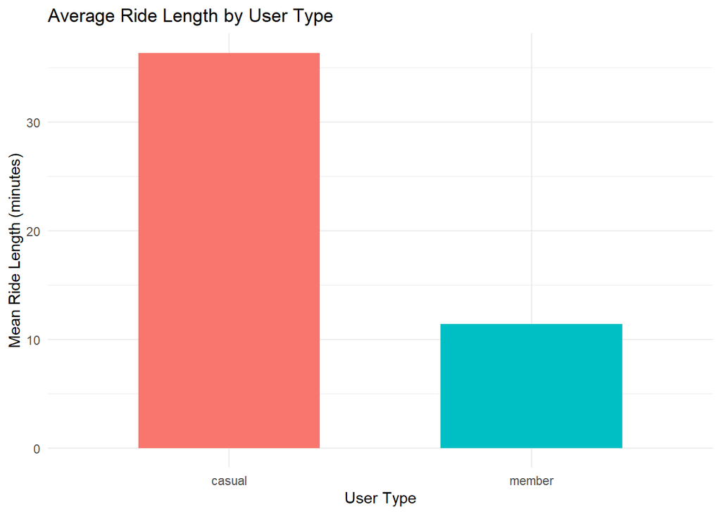

```r
# Load libraries
library(dplyr)
library(ggplot2)

# Bar chart: Average ride length by user type
fg1 <- ggplot(pivot_table, aes(x = usertype, y = Mean_min, fill = usertype)) +
  geom_col(width = 0.6) +
  labs(
    title = "Average Ride Length by User Type",
    x = "User Type",
    y = "Mean Ride Length (minutes)"
  ) +
  theme_minimal() +
  theme(legend.position = "none")

fg1
```

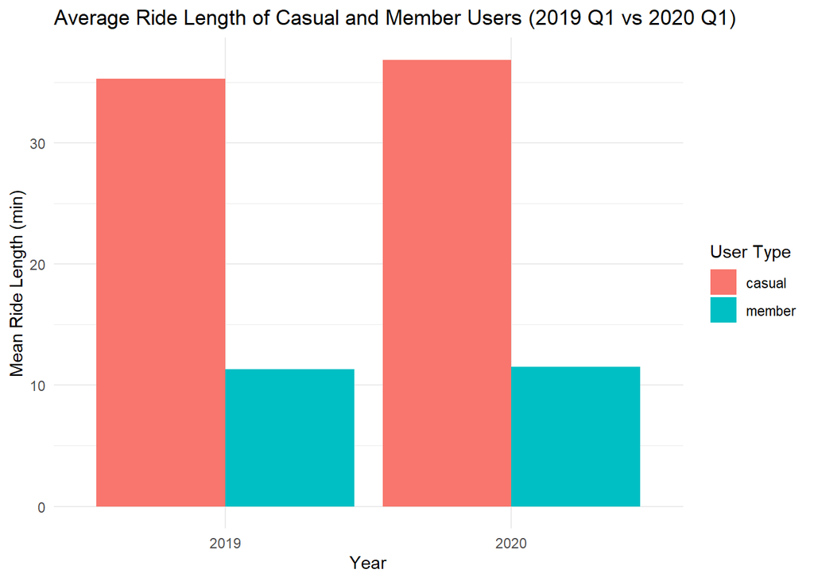

```r
# Average ride length by year and user type
fg1a <- ggplot(pivot_table2, aes(x = factor(Year), y = Mean_min, fill = usertype)) +
  geom_col(position = "dodge") +
  labs(title = "Average Ride Length of Casual and Member Users (2019 Q1 vs 2020 Q1)",
       x = "Year",
       y = "Mean Ride Length (min)",
       fill = "User Type") +
  theme_minimal()

fg1a
```

### 3.2 Average ride duration comparison on different days

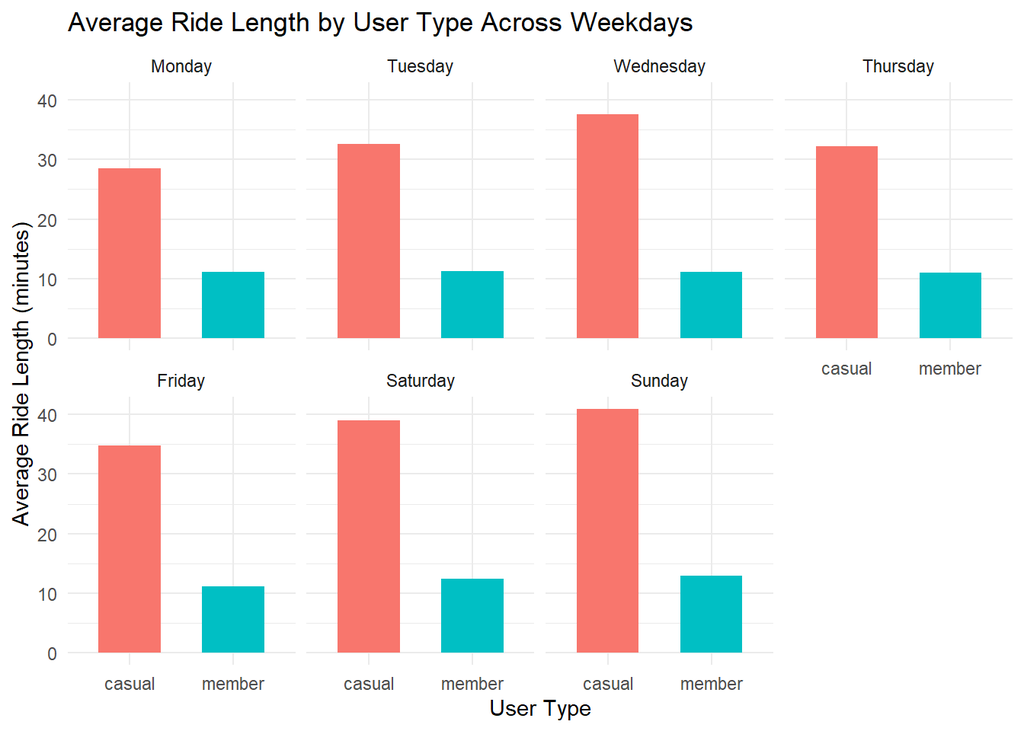

```r
#
combined_df_clean$day_of_week <- factor(
  combined_df_clean$day_of_week,
  levels = c("1","2","3","4","5","6","7"),
  labels = c("Monday","Tuesday","Wednesday","Thursday","Friday","Saturday","Sunday")
)

weekday_counts <- combined_df_clean %>%
  group_by(usertype, day_of_week) %>%
  summarise(Count = n(), .groups = "drop")


pivot_table <- combined_df_clean %>%
  group_by(day_of_week, usertype) %>%
  summarise(
    Mean_min = mean(ride_length_min, na.rm = TRUE),
    .groups = "drop"
  )

fg2 <- ggplot(pivot_table, aes(x = usertype, y = Mean_min, fill = usertype)) +
  geom_col(width = 0.6) +
  facet_wrap(~ day_of_week, ncol = 4) +
  labs(
    title = "Average Ride Length by User Type Across Weekdays",
    #subtitle = "Each panel represents one day of the week",
    x = "User Type",
    y = "Average Ride Length (minutes)",
    size = 4
  ) +
  theme_minimal() +
  theme(
    legend.position = "none",
    #strip.text = element_text(face = "bold")
  )


fg2
```

### 3.3 Number of rides comparison on different days

Members take many more rides on weekdays, reflecting regular commuting patterns. Casual users take more rides during weekends, confirming that recreational riding is more common among non-members. This figure highlights the distinct usage patterns between casual and member users and between weekdays and weekends.

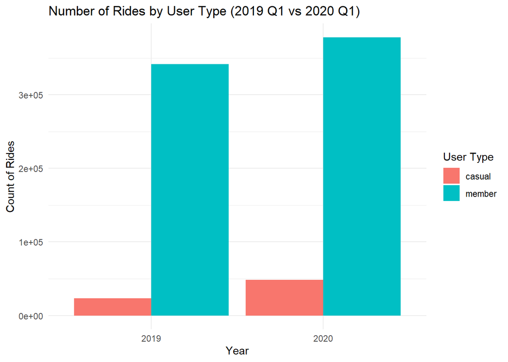

```r
# First, there is an overall comparison by user type
fg3<- ggplot(pivot_table2, aes(x = factor(Year), y = Count, fill = usertype)) +
  geom_col(position = "dodge") +
  labs(
    title = "Number of Rides by User Type (2019 Q1 vs 2020 Q1)",
    x = "Year",
    y = "Count of Rides",
    fill = "User Type"
  ) +
  theme_minimal()
fg3
```

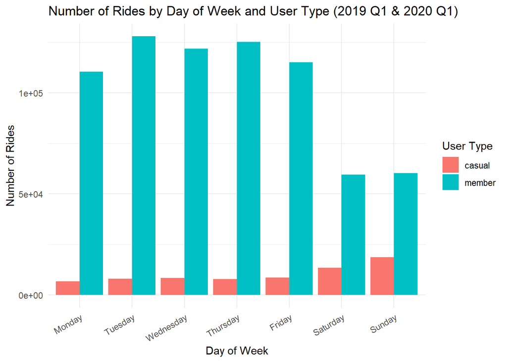

```r
#  Boxplot: Weekly ride count by user type
fg3a <- ggplot(weekday_counts,
       aes(x = day_of_week, y = Count, fill = usertype)) +
  geom_col(position = "dodge") +
  labs(
    title = "Number of Rides by Day of Week and User Type (2019 Q1 & 2020 Q1)",
    #subtitle = "Comparison between Casual and Member users (2019 Q1 vs 2020 Q1)",
    x = "Day of Week",
    y = "Number of Rides",
    fill = "User Type"
  ) +
  theme_minimal() +
  theme(
    axis.text.x = element_text(angle = 30, hjust = 1),
    #plot.title = element_text(face = "bold")
  )

fg3a
```

## 4. Summary

This case study analyzed bike-sharing usage using Divvy Q1 datasets from 2019 and 2020.

Descriptive statistics revealed clear differences between casual and member users.

Casual users tend to take longer rides, especially on weekends, while members primarily ride on weekdays with shorter durations.

Visualizations further highlighted these patterns, showing the distribution of rides by day of the week and average ride lengths by user type and year.

Overall, the analysis provides insights into user behavior patterns: members are more consistent weekday riders with shorter trips, whereas casual users take longer, less frequent rides, often on weekends. These findings can inform operational decisions and targeted marketing strategies for the bike-sharing company.